# Wavelet Prac

## Problem 1

A wavelet is convolved with the signal.

Create a signal $Y = sin(x)$, where $x$ are 16 equally spaced points between 0 and $2 \pi$.

Convolve the Haar father wavelet with the signal (2 points wavelet). Scale the wavelet so that it has L2 norm = 1. R function: `convolve`. Plot and check.

You should get these values:

```r
p <- c(-1.84945741e-16, 2.87606238e-01, 8.13088984e-01, 1.19798126e+00,
1.37573169e+00, 1.31560561e+00, 1.02799937e+00, 5.62642704e-01,
7.87132986e-16, -5.62642704e-01, -1.02799937e+00, -1.31560561e+00,
-1.37573169e+00 ,-1.19798126e+00 ,-8.13088984e-01, -2.87606238e-01,
-1.84945741e-16)
```

## Problem 2

**Algorithm:** The one-dimensional discrete wavelet transform.

$X$ is the signal to be transformed, $L$ is the low-pass filter, $H$ is the high-pass filter and $n$ is the number of filter bank iterations.

- function `dwt(X, L, H, n)`
  - A0 <- X. Initialization.
- for i = 0 . . . n − 1 do
- D_i+1 <- DS(Ai ∗ H). High-pass filter and downsample.
- A_i+1 <- DS(Ai ∗ L). Low-pass filter and downsample.
- return An, Dn, Dn−1, . . . , D1.

Your plot should look something like this:

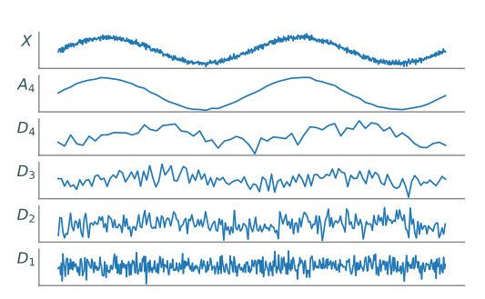

## Problem 3

Here are some signals with specific features: shift, changing frequency, all.

Use wavelets to extract these features.

### Regime Shift

```r
x <- seq(0, 1, length = 1024)

y <- sin(2*pi*5*x)

y[x>0.5] <- y[x>0.5] + 2

plot(x,y,type="l")
```

### Trend

```r
tt <- 1:512

trend <- 0.01 * tt
y_trend <- trend + rnorm(n, 0,0.5)

plot(tt, y_trend, type = "l", main = "Trend")
```

### Changing Frequency

```r
f <- seq(1,15,length=n)

y_chirp <-
  sin(
    2*pi*cumsum(f)/n
  )

plot(t,y_chirp,type="l",
     main="Changing Frequency")
```

### Several Features

```r
y_all <- 0.01 * t +
  ifelse(t > 256, 2, 0) +
  exp(-(t-150)^2/(2*25^2)) * sin(2*pi*t/10) +
  sin(2*pi*cumsum(seq(1,8,length=n))/n) +
  rnorm(n,0,0.3)

plot(t,y_all,type="l", main="Combined Signal")
```

## Packet

```r
center <- 250

wave_packet <- exp(-(tt - center)^2 / (2 * 30^2)) * sin(2*pi*t/12)

y_packet <- wave_packet + rnorm(n,0,0.2)

plot(t,y_packet,type="l", main="Wave Packet")
```

## Doppler

Here are some classic functions to generate data. Add noise and compare different methods to extract signal (splines, smoothing, wavelets.)

```r
library(wavethresh)

ff <- DJ.EX(plotfn = TRUE)
```

Donoho, D.L. and Johnstone, I.M. (1994), Ideal spatial adaptation by wavelet shrinkage. Biometrika, 81, 425–455 https://scispace.com/pdf/ideal-spatial-adaptation-by-wavelet-shrinkage-rg42etihwh.pdf

Addison, P.S. 2005. Wavelet transforms and the ECG: a review. Physiol. Meas. 26 R155 https://iopscience.iop.org/article/10.1088/0967-3334/26/5/R01/pdf